# Retrieve and plot images and cutouts from the AL / JWST Server.

```python
# Example notebook to retrieve and plot images and cutouts from the AL/JWST Server via its API.
#   Utilizes the ALWS_utils.ipynb notebook, which contains API helper classes and methods.
#
#  Written by: Tom Hicks. 2/22/2022.
#  Last Modified: Update for fetch cutout by filename.
```

```python
import matplotlib
import matplotlib.pyplot as plt
from matplotlib.colors import LogNorm

%matplotlib inline
```

```python
from astropy.coordinates import SkyCoord
from astropy.io import fits
from astropy.wcs import WCS
from astropy.utils.data import download_file
from astropy.visualization import MinMaxInterval, AsinhStretch, SqrtStretch, ImageNormalize
import astropy.units as u
```

```python
import pandas as pd
```

#### Load additional "helper" code to help manage interaction with the API:

```python
%run ALWS_utils.ipynb
```

#### Create an instance of the API "helper" class which uses the default server base URL (both just loaded).

```python
api = AlwsApi()
```

#### Authorize an existing user, storing the resulting JWT access token in the instance of the class

```python
## Uncomment the following two lines to see the response when authorization fails:
# resp = api.authorize('jfake@nowhere.com', 'invalid_pwd')
# print(resp.json())
resp = api.authorize('jfake@nowhere.com', 'testydjango2')
# print(resp.json())
```

## Get and plot an entire image from the AL/JWST image server

#### First, let's see what images are available from the image server:

```python
resp = api.get('imgmd/')
```

#### The response contains an array of dictionaries, each containing metadata about a single image file. With a little bit of work, we can read the image information into a Pandas DataFrame, for a nicer display:

```python
recs = []
for rec in get_results(resp):
    recs.append({k:v for (k,v) in rec.items() if k != 'metadata'})
pd.json_normalize(recs)
```

|  | file_name | file_size | md5sum | ra | dec | collection | filter |
| --- | --- | --- | --- | --- | --- | --- | --- |
| 0 | DC19_F090W.fits | 337230720 | 1f535332c87523c2d9d7bc70b0897897 | 53.157663 | -27.807520 | DC19 | F090W |
| 1 | DC19_F115W.fits | 337230720 | dadf3a2f7883a9355d9c2fefdc18445d | 53.157663 | -27.807520 | DC19 | F115W |
| 2 | DC19_F150W.fits | 337230720 | 7a0749ff4a636b016499fb5ef24e7f46 | 53.157663 | -27.807520 | DC19 | F150W |
| 3 | DC19_F200W.fits | 337230720 | 6a5f7c38ee53acb941f933454e42fd7f | 53.157663 | -27.807520 | DC19 | F200W |
| 4 | DC19_F277W.fits | 337230720 | 281435deeded127e7516b30c82c1261f | 53.157663 | -27.807520 | DC19 | F277W |
| 5 | DC19_F335M.fits | 337230720 | c23718c0ae18c36ff1426dd1b442d265 | 53.157663 | -27.807520 | DC19 | F335M |
| 6 | DC19_F356W.fits | 337230720 | 0eb2511c020307c8ad4d885719e1ad60 | 53.157663 | -27.807520 | DC19 | F356W |
| 7 | DC19_F410M.fits | 337230720 | 6ba34115e4c29dea815be588f6bdc02c | 53.157663 | -27.807520 | DC19 | F410M |
| 8 | DC19_F444W.fits | 337230720 | 792b63c6bf180140473d2ff658bc01e4 | 53.157663 | -27.807520 | DC19 | F444W |
| 9 | DC20_F090W.fits | 2666568960 | cc8674de41f7b1f52d0f91bdfb7cf5db | 53.155277 | -27.787295 | DC20 | F090W |
| 10 | DC20_F115W.fits | 2666568960 | 0d2e9ca4e298b003771ae7e5f3b47cf1 | 53.155277 | -27.787295 | DC20 | F115W |
| 11 | DC20_F150W.fits | 2666568960 | f0be0ea446d16cdcd83aabe9d8eaec17 | 53.155277 | -27.787295 | DC20 | F150W |
| 12 | DC20_F200W.fits | 2666568960 | a9cbeb91828f59e610a681f87a53e337 | 53.155277 | -27.787295 | DC20 | F200W |
| 13 | DC20_F277W.fits | 666645120 | b7f6487ffbec391b4615692f06db7c18 | 53.155277 | -27.787295 | DC20 | F277W |
| 14 | DC20_F335M.fits | 666645120 | 4d1cec78ccb29ee2d5f18fd38d44ea09 | 53.155277 | -27.787295 | DC20 | F335M |
| 15 | DC20_F356W.fits | 666645120 | cd68a3b6e3788cd414f7b18c5e5c8b87 | 53.155277 | -27.787295 | DC20 | F356W |
| 16 | DC20_F410M.fits | 666645120 | 66168329bd8aa8780ced656a599f2d02 | 53.155277 | -27.787295 | DC20 | F410M |
| 17 | DC20_F444W.fits | 666645120 | 69630226c2276b97ff52580337ebbc52 | 53.155277 | -27.787295 | DC20 | F444W |
| 18 | gds-050mas-f606w_drz_sci.fits.gz | 3615439098 | 0b88fa92e742165da03721dd7befc42c | 53.109667 | -27.829933 | HUBMOS | F606W |
| 19 | gds-050mas-f775w_drz_sci.fits.gz | 1627935107 | 8af257effb905cc4fbbee37e258ef478 | 53.109667 | -27.829933 | HUBMOS | F775W |
| 20 | gds-050mas-f814w_drz_sci.fits.gz | 2651260832 | 0ba7d44ac6324638fb2399624048596d | 53.109667 | -27.829933 | HUBMOS | F814W |
| 21 | gds-050mas-f850lp_drz_sci.fits.gz | 3513097658 | 7366143cef553b254c0066a1c023aba8 | 53.109667 | -27.829933 | HUBMOS | F850LP |
| 22 | gds-100mas-f098m_drz_sci.fits.gz | 71344622 | f59a010640b6de7c4e38377d0dbf15a8 | 53.109667 | -27.829933 | HUBMOS | F098M |
| 23 | gds-100mas-f105w_drz_sci.fits.gz | 191883121 | a861c6e30e5b9265f023743c2789e0ad | 53.109667 | -27.829933 | HUBMOS | F105W |
| 24 | gds-100mas-f110w_drz_sci.fits.gz | 8279871 | a7570ec6f0f378d89d0fece02134c2b8 | 53.109667 | -27.829933 | HUBMOS | F110W |
| 25 | gds-100mas-f125w_drz_sci.fits.gz | 262090293 | 51ac76e6f99302ed019b8ec13bf4811e | 53.109667 | -27.829933 | HUBMOS | F125W |
| 26 | gds-100mas-f140w_drz_sci.fits.gz | 229311235 | 1502fd85894b8f976aa386d31c87e20f | 53.109667 | -27.829933 | HUBMOS | F140W |
| 27 | gds-100mas-f160w_drz_sci.fits.gz | 376700819 | 77f87121ba2f91b26dca88c29b258771 | 53.109667 | -27.829933 | HUBMOS | F160W |
| 28 | goods_s_F090W_2018_08_29.fits | 908847360 | a5b92c3ff6169f9585482287de070000 | 53.164683 | -27.783111 | JADES | F090W |
| 29 | goods_s_F115W_2018_08_29.fits | 908847360 | 8386151b4596027fa9865b26d5aba2dc | 53.164683 | -27.783111 | JADES | F115W |
| 30 | goods_s_F150W_2018_08_29.fits | 908847360 | 272d32f05745979baa287f8956c189ce | 53.164683 | -27.783111 | JADES | F150W |
| 31 | goods_s_F200W_2018_08_29.fits | 908395200 | a8da1d48ac54b7a69f0d21aa3b79f2d2 | 53.164683 | -27.783111 | JADES | F200W |
| 32 | goods_s_F277W_2018_08_29.fits | 902730240 | 39c5310a7e15dc9cc2deb40b5c1f6435 | 53.164683 | -27.783111 | JADES | F277W |
| 33 | goods_s_F335M_2018_08_29.fits | 902214720 | 332a5c8817460745835890d4aaad65d9 | 53.164683 | -27.783111 | JADES | F335M |
| 34 | goods_s_F356W_2018_08_30.fits | 902214720 | 2f9510c434f0a511db3fbf64435c72a9 | 53.164683 | -27.783111 | JADES | F356W |
| 35 | goods_s_F410M_2018_08_30.fits | 902730240 | 4140cdbbb9f46d6809acd6fb0de34cf6 | 53.164683 | -27.783111 | JADES | F410M |
| 36 | goods_s_F444W_2018_08_31.fits | 902730240 | d543cf5d7d04988fb091481e0a2f3182 | 53.164683 | -27.783111 | JADES | F444W |
| 37 | HorseHead.fits | 1650240 | 2c9202ae878ecfcb60878ceb63837f5f | 85.274970 | -2.458265 | XTRAS | OG590 |
| 38 | m13.fits | 184320 | fe57e89d674e1e52071f674c60974968 | 250.422600 | 36.460200 | XTRAS | None |

#### Since memory is limited, let's select a **small** image to display. (The following assumes that the `HorseHead.fits` file was listed above. If not, subsitute another filename below).

```python
imgURL = api.compose('img/fetch/?filename=HorseHead.fits')
image_file = download_file(imgURL, http_headers=api.auth_header)
```

```python
## Alternatively, one can download the bytes into memory and then read them directly:
# resp = api.get('img/fetch/?filename=HorseHead.fits')
# if (resp.status_code == 200):
#     image_file = io.BytesIO(resp.content)
# else:
#     print(resp.json())  # print error message
```

#### After downloading and opening the image, we can inspect its headers and properties.

```python
image_hdus = fits.open(image_file)
image_hdus.info()
```

```
Filename: /tmp/astropy-download-1283-myu0qg3m
No.    Name      Ver    Type      Cards   Dimensions   Format
  0  PRIMARY       1 PrimaryHDU     161   (891, 893)   int16
  1  er.mask       1 TableHDU        25   1600R x 4C   [F6.2, F6.2, F6.2, F6.2]
```

```python
image = image_hdus[0].data
image.shape
```

```
(893, 891)
```

#### Finally, we can plot the image.

[figure not shown]

```python
plt.imshow(image, cmap='magma')
plt.colorbar()
```

## Get and plot a cutout from the AL/JSWT image server

#### To make a cutout from an image, provide the unique filename for the image. Select a filename from the image table we made above and provide it with the other cutout request parameters:

```python
params={'ra': '53.1617', 'dec': '-27.78', 'sizeArcSec': '10', 'filename': 'DC20_F444W.fits'}
resp = api.get('cuts/fetch_cutout_by_filename/', params)
if (resp.status_code == 200):
    co_hdus = fits.open(io.BytesIO(resp.content))
else:
    print(resp.json())  # print error message
```

#### You can also make a cutout using the unique key for the image, which is called the 'md5sum'. To use the same image as in the previous example, you would put its md5sum into the cutout request parameters (instead of the filename) and call the **fetch_cutout** URL.

```python
# params={'ra': '53.1617', 'dec': '-27.78', 'sizeArcSec': '10', 'md5sum': '69630226c2276b97ff52580337ebbc52'}
# resp = api.get('cuts/fetch_cutout/', params)
# if (resp.status_code == 200):
#     co_hdus = fits.open(io.BytesIO(resp.content))
# else:
#     print(resp.json())  # print error message
```

#### If there was no error message above, the server made the requested cutout and sent it. Jupyter Lab saved the bytes of the image in memory and we "opened" (loaded) them from memory, as a FITS file.

#### After downloading and opening the image, we can inspect its headers and properties:

```python
co_hdus.info()
```

```
Filename: <class '_io.BytesIO'>
No.    Name      Ver    Type      Cards   Dimensions   Format
  0  PRIMARY       1 PrimaryHDU      36   (167, 167)   float32
```

```python
co_hdu = co_hdus[0]
wcs = WCS(co_hdu.header)
cutout = co_hdu.data
cutout.shape
```

```
(167, 167)
```

#### Now, we can plot the image data:

```python
# norm_cutout = ImageNormalize(cutout, interval=MinMaxInterval(), stretch=AsinhStretch())
norm_cutout = ImageNormalize(cutout, interval=MinMaxInterval(), stretch=SqrtStretch())
```

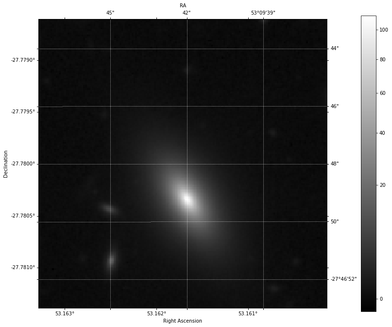

```python
fig = plt.figure(figsize=(14,14))
ax = fig.add_subplot(111, projection=wcs)
plt.imshow(cutout, origin='lower', cmap=plt.cm.gray, norm=norm_cutout)
plt.colorbar(pad=0.09, shrink=0.8)
ax.coords[0].set_axislabel('Right Ascension')
ax.coords[0].set_format_unit(u.degree, decimal=True)
ax.coords[1].set_axislabel('Declination')
ax.coords[1].set_format_unit(u.degree, decimal=True)

overlay = ax.get_coords_overlay('fk5')
overlay.grid(color='white', ls='dotted')
overlay[0].set_axislabel('RA')
overlay[1].set_axislabel(' ')
```

## Query for and plot a cutout from the AL/JWST image server

#### If you do not need a specific image, you can query for the **first** image which meets some criteria.

#### For example, get a cutout of 10 arc seconds from the first image, with the specified filter, from the specified collection, which contains the specified point:

```python
params={'ra': '53.1617', 'dec': '-27.78', 'sizeArcSec': '10', 'filter': 'F356W', 'collection': 'DC20'}
resp = api.get('cuts/query_fetch_cutout/', params)
if (resp.status_code == 200):
    co_hdus = fits.open(io.BytesIO(resp.content))
else:
    print(resp.json())  # print error message
```

#### Again, we can plot the image data.

```python
# norm_cutout = ImageNormalize(cutout, interval=MinMaxInterval(), stretch=AsinhStretch())
norm_cutout = ImageNormalize(cutout, interval=MinMaxInterval(), stretch=SqrtStretch())
```

[figure not shown]

```python
fig = plt.figure(figsize=(14,14))
ax = fig.add_subplot(111, projection=wcs)
plt.imshow(cutout, origin='lower', cmap=plt.cm.gray, norm=norm_cutout)
plt.colorbar(pad=0.09, shrink=0.8)
ax.coords[0].set_axislabel('Right Ascension')
ax.coords[0].set_format_unit(u.degree, decimal=True)
ax.coords[1].set_axislabel('Declination')
ax.coords[1].set_format_unit(u.degree, decimal=True)

overlay = ax.get_coords_overlay('fk5')
overlay.grid(color='white', ls='dotted')
overlay[0].set_axislabel('RA')
overlay[1].set_axislabel(' ')
```